# Who Benefits The Economy More

Maggie McEllistrem

## Project thoughts

Part 1: Question and Hypothesis

Do democrats or republicans have a more positive impact on the economy’s percent GDP during a 64 year period? Typically a Republican president would be assumed to make the economy more successful rather than a Democratic president. Republican presidents focus more on businesses, deregulation within businesses, tax reduction and energy affordability. These traits of a typical Republican president would likely boost the success of the economy. Therefore, my hypothesis is that a Republican president is more likely to have a positive impact on the economy than a Democratic president during the 64 year period my data is collected from.

Greater economic success during the Nixon, Ford, Reagan, George H.W. Bush, George W. Bush, and Trump administrations would prove my thesis correct. While, greater success within the economy during the Kennedy, Johnson, Carter, Clinton, Obama, and Biden administrations would prove that my hypothesis is incorrect. This is an important hypothesis to test because it helps voters understand which presidential party did a better job at helping boost the economy in the past. The growth and health of the economy is a very important factor for many voters when choosing which political party to vote for. It is important to do this type of test because forming a simple graph may be misleading or coincidental. We need to do a hypothesis test in order to find out if there is an actual difference in the economies growth between Republicans and Democrats to make sure that a certain outcome is not just due to random chance.

Part 2: Data

The data used in my experiment is compiled by the World Bank and is gathered from National Statistical Offices. The explanatory/predictor variable in my experiment is whether there was a Republican president. The response/outcome variable is the economic performance of the Republican president which will be measured in percent GDP. My data will cover the annual GDP growth percentage. In order to evaluate weather my hypothesis is true or not I will use a two-sample t-test to compare the average GDP growth rate between Republicans and Democrats. My null hypothesis is that there is no difference in mean GDP growth between Republican and Democratic parties. While my hypothesis is that the republican party on average has a higher average GDP and therefore a more positive impact on the economy.

If the p-value from the two-sample t-test is less than or equal to 0.05, the null hypothesis will be rejected, and my hypothesis that the republican party has a higher average GDP will be supported. If the p-value in this test is greater than 0.05 the null hypothesis will fail to be rejected, that there is no difference in mean GDP growth between Republicans and Democrats. This would mean that there is not enough evidence supporting my hypothesis to accept that Republicans benefit the economy more.

```r
my_data <- read_csv("~/Downloads/API_NY/API_NY.GDP.MKTP.KD.ZG_DS2_en_csv_v2_260.csv", skip = 3)
```

```
## ──────────────────────────────────────────────────────── Delimiter: "," chr
## (4): Country Name, Country Code, Indicator Name, Indicator Code dbl (64): 1961,
## 1962, 1963, 1964, 1965, 1966, 1967, 1968, 1969, 1970, 1971, ... lgl (3): 1960,
## 2025, ...71
```

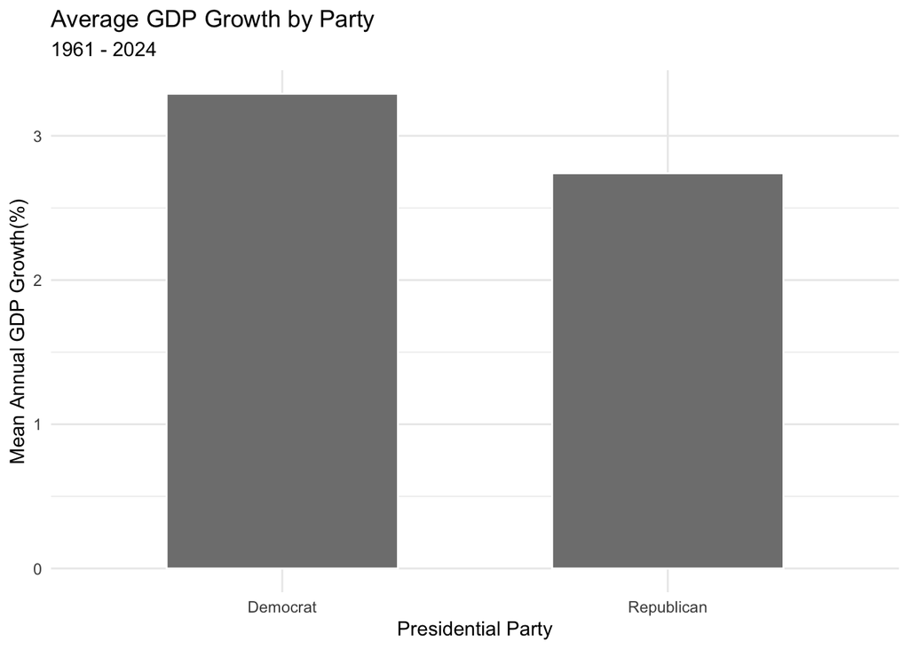

Part 3: Results

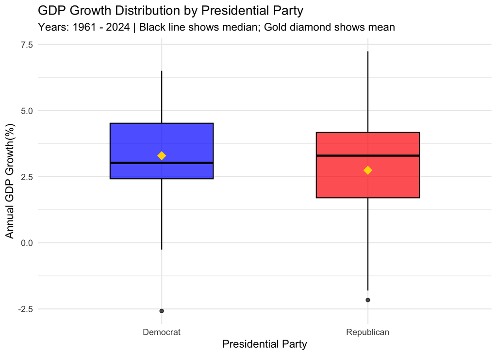

```
##
## Call:
## lm(formula = Growth ~ party, data = us_growth)
##
## Coefficients:
##     (Intercept)  partyRepublican
##           3.292           -0.551
```

| term | estimate | std.error | statistic | p.value |
| --- | --- | --- | --- | --- |
| (Intercept) | 3.292 | 0.377 | 8.728 | 0.000 |
| partyRepublican | -0.551 | 0.547 | -1.007 | 0.318 |

Analysis of Results:

The p-value is 0.318, because this is much higher than 0.05 this means that the my result is not statistically significant. There is a 31.8% chance that this difference in GDP growth percent happened purely by random luck. Because the p-value is greater than 0.05 we fail to reject the null hypothesis. This means the observed difference in Democrats and Republicans economic success is likely due to random changes in the economy occurring rather than it being due to the actual presidency.

The difference in means of GDP between democrats and republicans is 0.55 which is substantively meaningful. This is substantively meaningful because this is a difference of billions of dollars of economic activity between the growth of Democrats and Republican parties. But, this is not statistically significant because of our large p-value. We should not interpret our results that Republican policies cause lower GDP growth than Democrats causally. We should not interpret these results causally because of multiple confounding variables that could have impacted the results of the experiment. Some confounding variables may be that the state of the economy can drive who wins an election therefore our data would be skewed. Another may be the economic policies that are put in place by one president can have effects later on that isn’t during the time of their parties presidency.There may be many other reasons the economy could be effected due to a factor besides the president at the time.

Part 4: Conclusion

```r
library(readr)
my_data <- read_csv("~/Downloads/API_NY/API_NY.GDP.MKTP.KD.ZG_DS2_en_csv_v2_260.csv", skip = 3)
library(tidyverse)
library(ggplot2)
library(broom)
us_growth <- my_data |>
  filter(`Country Name` == "United States") |>
   pivot_longer(cols = `1961`:`2024`, names_to = "Year", values_to = "Growth") |>
   mutate(year = as.numeric(Year)) |>
   mutate(party = case_when(
    year %in% c(1961:1963, 1963:1969, 1977:1981, 1993:2001, 2009:2017) ~ "Democrat",
    year %in% c(1969:1974, 1974:1977, 1981:1989, 1989:1993, 2001:2009, 2017:2021 ) ~ "Republican",
    )) |>
  filter(party %in% c("Democrat", "Republican")) |>
   filter(!is.na("Other"))

us_growth |>
  group_by(party) |>
  summarize(mean_growth = mean(Growth, na.rm = TRUE)) |>
  ggplot(aes(x = party, y = mean_growth)) +
  geom_col(fill = "grey50", color = "white", width = 0.6) +
  labs(
    title = "Average GDP Growth by Party",
    subtitle = "1961 - 2024",
    x = "Presidential Party",
    y = "Mean Annual GDP Growth(%)"
  ) +
  theme_minimal() +
  theme(legend.position = "none")

 us_growth <- my_data |>
  filter(`Country Name` == "United States") |>
   pivot_longer(cols = `1961`:`2024`, names_to = "Year", values_to = "Growth") |>
   mutate(year = as.numeric(Year)) |>
   filter(!is.na(Growth))

us_growth <- us_growth |>
  mutate(party = case_when(
    year %in% c(1961:1963, 1963:1969, 1977:1981, 1993:2001, 2009:2017) ~ "Democrat",
    year %in% c(1969:1974, 1974:1977, 1981:1989, 1989:1993, 2001:2009, 2017:2021 ) ~ "Republican",
    TRUE ~ "Other"
    )) |>
   filter(party != "Other")

us_growth |>
  ggplot(mapping = aes(x = party, y = Growth, fill = party)) +
  geom_boxplot(color = "black", width = 0.5, alpha = 0.7) +
  stat_summary(fun = mean, geom = "point", shape = 18, size = 4, color = "gold") +
  scale_fill_manual(values = c("Democrat" = "blue", "Republican" = "red")) +
  labs(y = "Annual GDP Growth(%)",
       x = "Presidential Party",
       fill = "party",
       title = "GDP Growth Distribution by Presidential Party",
       subtitle = "Years: 1961 - 2024 | Black line shows median; Gold diamond shows mean"
       ) +
    theme_minimal() +
    theme(legend.position = "none")

fit <- (lm(Growth ~ party, data = us_growth))
fit
tidy(fit) |>
  knitr::kable(digits = 3)
```